# Identification and diagnosis of outlier samples

Jim Zhang

2018-03-02

This procedure requires the following inputs:

- A data matrix with genes or other variables as rows and samples as columns
- Samples (column names of the data matrix) were split into one to any number of groups, there should be at least 4 samples in each group for the outlier identification to work properly
- Specify the cutoff values of *NMN* (minimal number of samples in each group) and *NSD* (Number of standard deviations).
- Optionally, gene annotation and a collection of predefined gene sets for functional categorization of genes responsible for the outliers

*[Go to project home](https://github.com/zhezhangsh/RoCA)*

# 1 Description

## 1.1 Project

Transcriptome of preterm human blood

## 1.2 Experimental design

RNA-seq experiments were done on preterm human blood. Samples include 4 groups of 32 samples: 2 gender X 2 age (less than 30 weeks and more than 39 weeks); 8 samples per group.

## 1.3 Analysis

*[Go to project home](https://github.com/zhezhangsh/RoCA)*

# 2 Analyses and results

The data set includes **24617** genes and **32** samples in **4** groups.

## 2.1 Outlier detection

The following steps were applied to identify outlier samples:

- Given a data matrix of genes and samples, split samples into predefined sample groups, so each group includes only biological or technical replicates.
- Calculate the Pearson’s correlation coeffecients between each pair of samples in the same group, and then the average correlation coefficients of each sample to all the other samples in the same group, *Ms*. However, if a group has less than 4 samples, samples in this groups will be compared to samples in all groups.
- Calculate *NSDi*, or the number of standard deviations, for each sample *(Ms[i]-mean(Ms[-i]))/sd(Ms[-i])*, where *Ms[-i]* is the vector of *Ms* without the sample *i*.
- Identify outliers with mean correlation coefficient *Ms[i]* less than **0.975** and **1.5** standard deviations below mean(Ms[-i]).

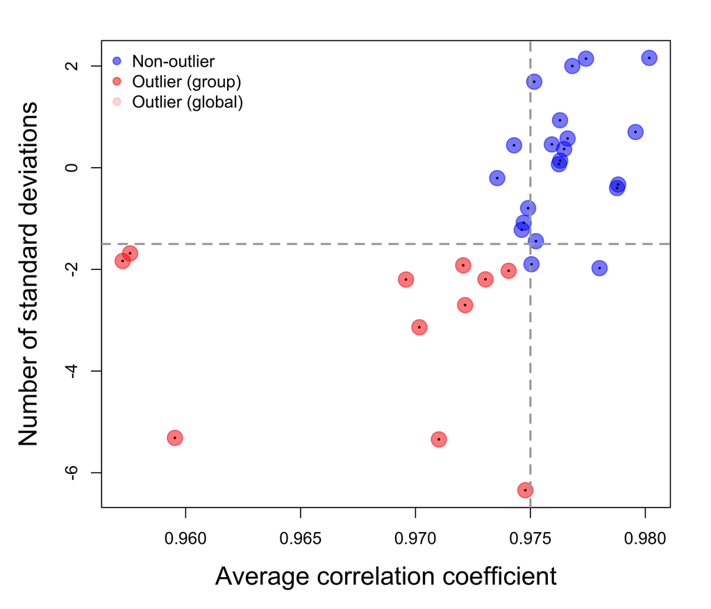

**Figure 1** Each dot represents a sample. The x-axis is the average correlation correlation between each sample and other samples of the same group (larger groups) or the whole data set (smaller groups). The y-axis is the number of standard deviations of each sample away from the averages of the other samples. Red indicates ouliter samples (in larger groups) identified as outliers by comparing them to all the other samples in the same group. Pink indicates outlier samples (in smaller groups) identified as outliers by comparing them to the other samples in the whole data set. The within gorup comparison generally provides stronger evidence of determing outliers. On the other hand, depending on how the samples are grouped in the data set, the evidence supporting global outliers varies, and should be evaluated further before determining they are indeed outliers. The remaining analyses of this report will only be applied to outliers identified by within group comparison.

*[Go to project home](https://github.com/zhezhangsh/RoCA)*

## 2.2 Outliers vs. non-outliers

- 0174
- 1003
- 0112
- 177
- 0114
- 265
- 228
- 263
- 00131
- 0107
- 137

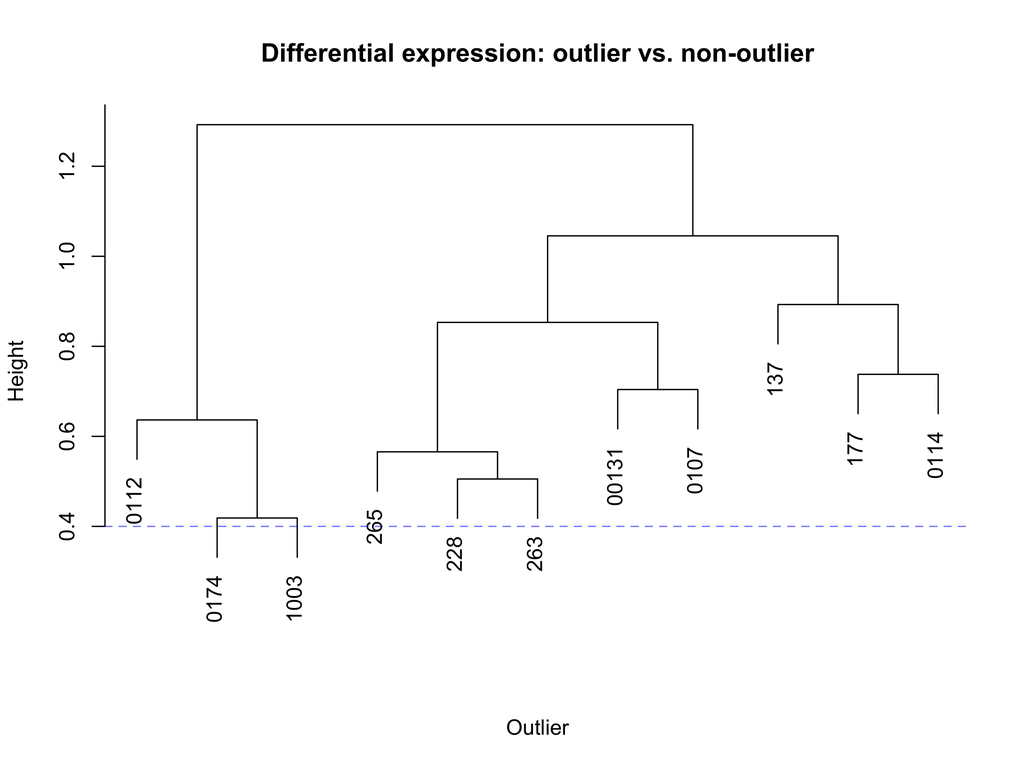

**Figure 2** Clustering of outliers based on their difference with the non-outliers in the same group. If multiple outliers have similar global pattern of changes relative to their non-outliers, these outliers could be the consequence of the same systematic bias. With the cutoff of correlation coefficient equal to 0.6, the following outliers are clustered together:

No outliers can be grouped together.

### 2.2.1 Selection of top genes

Top genes having the biggest difference between outlier and corresponding non-outliers can provide very valuable information about the cause of the outliers. The following criteria are used to select top genes with most changes in the outliers comparing to the average of their corresponding non-outliers:

- For each outlier, two lists of top genes are selected, corresponding to two opposite directions of change.
- The changes in the outlier are greater than 2 standard deviations of the non-outliers.
- From the remaining genes, pick the top 250 with the largest changes in the outlier.
- From the remaining genes, pick those with changes greater than 2, or the top 100 genes having the largest changes, which ever gives more genes.

**Table 1.** The numbers of top genes selected from each outlier.

|  | Higher in outlier | Low in outlier |
| --- | --- | --- |
| 0174 | 250 | 250 |
| 1003 | 250 | 250 |
| 0112 | 206 | 153 |
| 177 | 208 | 250 |
| 0114 | 215 | 210 |
| 265 | 250 | 250 |
| 228 | 250 | 250 |
| 263 | 250 | 250 |
| 00131 | 250 | 250 |
| 0107 | 250 | 250 |
| 137 | 182 | 245 |

### 2.2.2 Gene set enrichment analysis

Top genes selected from each outliers by the last step were mapped to predefined genesets collected from:

- BioSystems
- KEGG
- MSigDb
- OMIM
- PubTator

The full gene set collection of a few model animals can be downloaded from [here](https://github.com/zhezhangsh/RoCA/tree/master/data/gene.set).

Enrichment of each gene set in top genes was tested by Hypergeometric test.

**Table 2A.** The number of gene sets significantly enriched in top increasing genes of each outlier.

|  | BioSystems | KEGG | MSigDb | OMIM | PubTator |
| --- | --- | --- | --- | --- | --- |
| 0174 | 278 | 20 | 291 | NULL | 148 |
| 1003 | 173 | 12 | 226 | NULL | 196 |
| 0112 | 288 | 20 | 317 | NULL | 90 |
| 177 | 135 | 3 | 89 | NULL | 25 |
| 0114 | 121 | 13 | 96 | NULL | 28 |
| 265 | 449 | 35 | 332 | NULL | 173 |
| 228 | 706 | 63 | 393 | NULL | 222 |
| 263 | 443 | 38 | 339 | NULL | 147 |
| 00131 | 125 | 14 | 88 | NULL | 86 |
| 0107 | 131 | 6 | 132 | NULL | 108 |
| 137 | 170 | 4 | 73 | NULL | 23 |

**Table 2B.** The number of gene sets significantly enriched in top decreasing genes of each outlier.

|  | BioSystems | KEGG | MSigDb | OMIM | PubTator |
| --- | --- | --- | --- | --- | --- |
| 0174 | 522 | 80 | 973 | NULL | 578 |
| 1003 | 478 | 54 | 1039 | NULL | 619 |
| 0112 | 92 | 15 | 83 | NULL | 27 |
| 177 | 437 | 49 | 650 | NULL | 323 |
| 0114 | 217 | 37 | 233 | NULL | 135 |
| 265 | 38 | NULL | 21 | NULL | 12 |
| 228 | 39 | 4 | 26 | NULL | 305 |
| 263 | 97 | 37 | 55 | NULL | 37 |
| 00131 | 521 | 112 | 613 | NULL | 277 |
| 0107 | 227 | 43 | 284 | NULL | 133 |
| 137 | 240 | 35 | 497 | NULL | 264 |

*[Go to project home](https://github.com/zhezhangsh/RoCA)*

# 3 Appendix

Check out the **[RoCA home page](http://zhezhangsh.github.io/RoCA)** for more information.

## 3.1 Reproduce this report

To reproduce this report:

1. Find the data analysis template you want to use and an example of its pairing YAML file [here](https://github.com/zhezhangsh/RoCA/wiki/Templates-and-examples) and download the YAML example to your working directory
2. To generate a new report using your own input data and parameter, edit the following items in the YAML file:
   - *output* : where you want to put the output files
   - *home* : the URL if you have a home page for your project
   - *analyst* : your name
   - *description* : background information about your project, analysis, etc.
   - *input* : where are your input data, read instruction for preparing them
   - *parameter* : parameters for this analysis; read instruction about how to prepare input data
3. Run the code below within *R Console* or *RStudio*, preferablly with a new R session:

```r
if (!require(devtools)) { install.packages('devtools'); require(devtools); }
if (!require(RCurl)) { install.packages('RCurl'); require(RCurl); }
if (!require(RoCA)) { install_github('zhezhangsh/RoCAR'); require(RoCA); }

CreateReport(filename.yaml);  # filename.yaml is the YAML file you just downloaded and edited for your analysis
```

If there is no complaint, go to the *output* folder and open the *index.html* file to view report.

*[Go to project home](https://github.com/zhezhangsh/RoCA)*

*END OF DOCUMENT*